# Business Analytics - Final Project

Critical Thinking Group 5

Arindam Barman

Mohamed Elmoudni

Shazia Khan

Kishore Prasad

# 1 Abstract:

# 2 Key words:

# 3 Introduction:

The data set contains approximately 41188 obs. of 21 variables.  
This dataset is based on “Bank Marketing” UCI dataset (please check the description at: http://archive.ics.uci.edu/ml/datasets/Bank+Marketing). The data is enriched by the addition of five new social and economic features/attributes (national wide indicators from a ~10M population country), published by the Banco de Portugal and publicly available at: https://www.bportugal.pt/estatisticasweb.\

The binary classification goal is to predict if the client will subscribe a bank term deposit (variable y).

This dependent variable tells whether the client will subscribe a bank term deposit or not. This is a binary variable and as such we will be using a Logistic Regression Model.

# 4 Literature review:

## 5.1.2 Variable identification

First let’s display and examine the data dictionary or the data columns as shown in table 1

We notice that the variables are numerical, categorical and binary. The response variable y is binary.

Binomial Logistic regression is the appropriate regression analysis to conduct when the dependent variable is dichotomous (binary). Like all regression analyses, the logistic regression is a predictive analysis. Logistic regression is used to describe data and to explain the relationship between one dependent binary variable and one or more metric (interval or ratio scale) independent variables.

## 5.1.3 Preliminary Data Analysis

## 5.1.4 Analysis of Predictor variable

Variable Analysis

[output not shown]

## 5.1.5 Proportion of Response Variables

# 5.2 Data Preparation

-Convert Binary to 0 and 1  
-Create dummy variables  
-Data Summary Analysis  
-Correlation of Variables with y

## 5.2.1 Convert Binary yes and no to 0 and 1

Now in order to prepare the data for modeling, we need to update Yes = 1 and No = 0.

## 5.2.2 Create dummy variables

Now we need to create dummy variables to find out the relationship between y variables and dependent variables, for all categorical variables.

### Prepare test data

We will treat the test data the same way as the train data, and then apply models created using the treated train data.

## 2.5 Outliers Handling

## 5.2.6 Analysis the link function for given variables

In this section, we will investigate how our initial data aligns with a typical logistic model plot.

Recall the Logistic Regression is part of a larger class of algorithms known as Generalized Linear Model (glm). The fundamental equation of generalized linear model is:

$g(E(y)) = a+ Bx_1+B_2x_2+ B_3x_3+...$

where, g() is the link function, E(y) is the expectation of target variable and $B_0 + B_1x_1 + B_2x_2+B_3x_3$ is the linear predictor ( $B_0,B_1,B_2, B_3$ to be predicted). The role of link function is to ‘link’ the expectation of y to linear predictor.

In logistic regression, we are only concerned about the probability of outcome dependent variable ( success or failure). As described above, g() is the link function. This function is established using two things: Probability of Success (p) and Probability of Failure (1-p). p should meet following criteria: It must always be positive (since p >= 0) It must always be less than equals to 1 (since p <= 1).

The main objective in the transformations is to achieve linear relationships with the dependent variable (or, really, with its logit).

# Methodology

## Business Understanding :

## Data Exploration :

5.1 Data Exploration

In section we will explore and gain some insights into the dataset by pursuing the below high level steps and inquiries:  
-Variable identification  
-Understanding predictor variables relationship with response variable -Missing values and Unique Values  
## Data Preparation :

## Modeling:

### Logistics Regression:

Logistic Regression is a probabilistic statistical classification model. It is also used to predict a binary response from a binary predictor.Logistics model doesn’t’t suffer a lot from severe class imbalance. Logistic Regression creates log odds of the response as a linear function of predictor variables. Many of the categorical predictors in the data set for this project have sparse and unbalanced distributions. Using logistics model with the given set of data would need adjustment of variables to fine tune the model.

### Classification Tree

Classification Tree is used to predict the outcome of a categorical response variable.The purpose of the analyses via tree-building algorithms is to determine a set of logical conditional split that permit accurate classification of cases and accurate prediction.Effectiveness of classification tree model with binary variable is one of the reason for selection for this analysis study. This model though has problem with over fitting. We will also create RandomForest model to overcome that.’

### RandomForest Model

Random Forests grows many classification trees for given set of response and predictor variables. Each tree gives a classification, and all the outputs from different trees are “votes” for that class. The forest chooses the classification having the most votes (over all the trees in the forest). Over fitting problem with the classification tree can be overcome by this approach with weighted average of more number of trees. This method is good for prediction but a little bit difficult to interpret. Since we are facing the binary category,Random Forest is a good classification method to try.

## Evaluation

There are number of ways to evaluate the regression and classification models based on the purpose like prediction, classification, variable selection etc. In the given business scenario objective is to classification of the response variable by building a model that can predict likelihood of response from Customer. Following evaluation criteria we have used for model evaluation-  
(1) The Hosmer-Lemeshow test assesses the model calibration and how predicted values tend to match the predicted frequency when split by risk decides. This test will be used for Logistics regression model validation.  
(2) AUC along with Model Accuracy will be used for model evaluation. Accuracy is calculated based on certain threshold where as AUC is overall performance evaluation of model as various points.AUC criteria will be given more weight age for model evaluation in this case.

# Experimentations:

In this section experimentation will be carried out with the data by formulating three different types of models with three different approaches. Following are the three different approaches that will be used here-

-Model 1- This model will be created by using logit function of Generalized Logistics Model(GLM).

-Model 2: This model will be created by using Classification tree function.

-Model 3- This model will be created by using classification technique RandomForests model.

There are two data set given with the business case training and test set. Training set will be used to train the model and the test set will be used to evaluate the model performance.

### Logistics regression- Model 1:

Logistics regression function GLM has been used to classify the campaign response variable. Basic model generated by using GLM function has been enhanced by making necessary adjustments to non associated predictor variables shown as “NA” in basic model output. Next the model has been validated by using k=5 fold cross validation press to do necessary adjustment to the model.

### Interpretation from Logistics Regression model:

There were total 10 iterations been performed before final selection of variables were made. AIC value from model 1 and model1_update(enhanced) model were same 13776. Hence removing variables from basic model does not help performance wise but reduced complexity with less degrees of freedom.By using k=5 cross validation, ($delta) error value came out to be low 0.06289177.

Table below provide details on significance of the variables and its odd ratio-

Signifcant Variables model 1

[output not shown]

### Classification Tree- Model 2:

The basic idea of classification tree model is to predict a response variable y for the campaign from predictor variables. Model does this by growing a binary tree. At each node in the tree, a test is applied to one of the inputs. Depending on the outcome of the test two routes to be followed left or right. Eventually a leaf node is reached where a prediction is made about the binary outcome of campaign response. Model 2 has been rated using the Classification function from ROCR package.Basic model has been optimized using prune function.

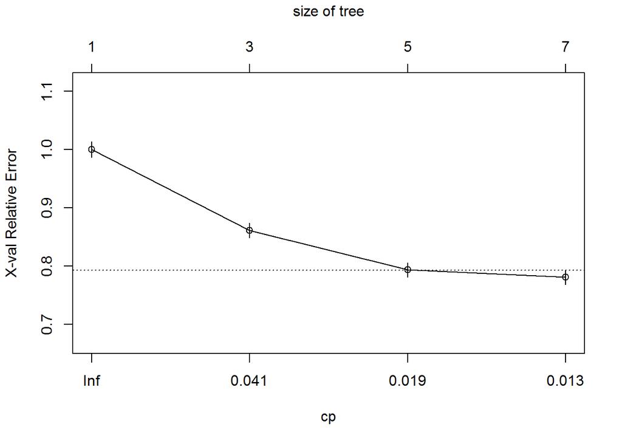

### Interpretation of Classification Tree Model :

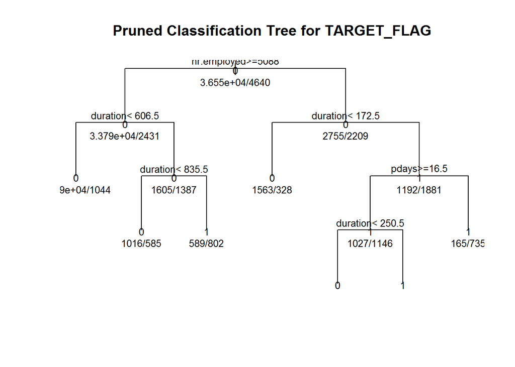

### RandomForest- Model 3:

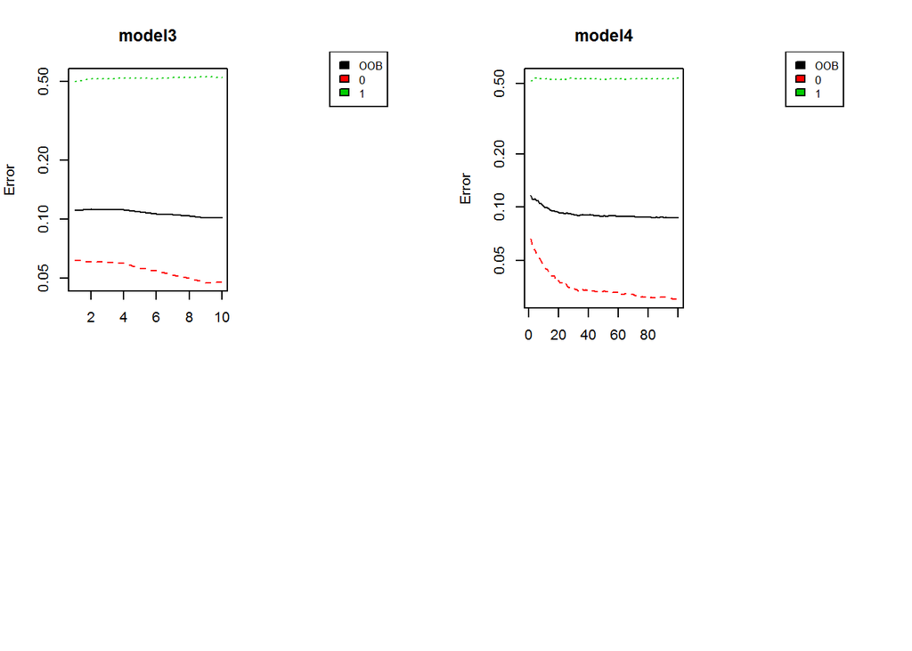

### Interpretation of RandomForest:

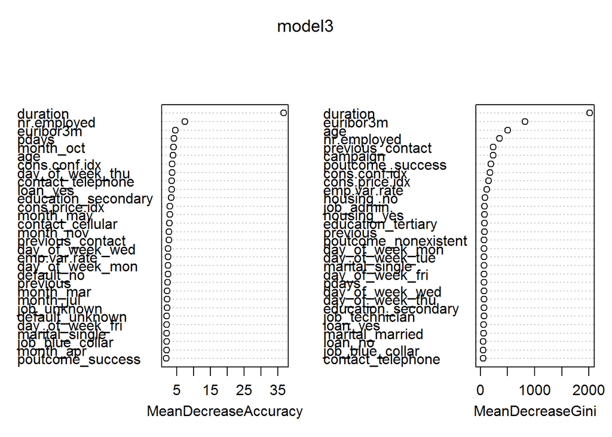

# Results :

## Results from Regression Model

Model 1 evaluation KPIs

|  | Accuracy | Error_Rate | Precision | sensitivity | specificity | F1_Score | AUC |
| --- | --- | --- | --- | --- | --- | --- | --- |
| 1 | 0.9142996 | 0.0857004 | 0.4323725 | 0.6678082 | 0.9331069 | 0.3607211 | 0.7029638 |

From above table it can be seen Logistics Regression model has a very high accuracy rate of 91.42% when model was evaluated using the validation data set. Though the AUC value for this model was comparatively lower 0.702 which indicates not good fitment of the model.

```
##
##  Hosmer and Lemeshow goodness of fit (GOF) test
##
## data:  model1_update$y, fitted(m)
## X-squared = 14.926, df = 8, p-value = 0.0606
```

By using Hosmer-Lemeshow goodness-of-fit (GOF) tests when model was evaluated p value came to be greater than 0.05. With this test if the p value is lower than 0.05 model is rejected and if it’s high, then the model passes the test. Regression model passed this test.

## Results from Classification Tree- Model 2

|  | Accuracy | Error_Rate | Precision | sensitivity | specificity | F1_Score | AUC |
| --- | --- | --- | --- | --- | --- | --- | --- |
| 2 | 0.918184 | 0.081816 | 0.5343681 | 0.6548913 | 0.9440149 | 0.4377405 | 0.8650875 |

It can be seen from the table above, this model 2 has also very high accuracy rate of 91.81% which is very good.This model has AUC value of 0.865 which seem to be inline with given high accuracy.

## Results from RandomForest Model

|  | Accuracy | Error_Rate | Precision | sensitivity | specificity | F1_Score | AUC |
| --- | --- | --- | --- | --- | --- | --- | --- |
| 3 | 0.9798495 | 0.0201505 | 0.8447894 | 0.9670051 | 0.9812081 | 0.8386306 | 0.9206226 |

# 5 Discussion and Conclusions:

Comparison of 3 Model3

|  | Model_No | Accuracy | Error_Rate | Precision | sensitivity | specificity | F1_Score | AUC |
| --- | --- | --- | --- | --- | --- | --- | --- | --- |
| 1 | GLM_model1 | 0.9142996 | 0.0857004 | 0.4323725 | 0.6678082 | 0.9331069 | 0.3607211 | 0.7029638 |
| 2 | CRT_model2 | 0.9181840 | 0.0818160 | 0.5343681 | 0.6548913 | 0.9440149 | 0.4377405 | 0.8650875 |
| 3 | RF_model3 | 0.9798495 | 0.0201505 | 0.8447894 | 0.9670051 | 0.9812081 | 0.8386306 | 0.9206226 |

Among the negative variables “emp.var.rate” has negative impact on response. As negative rate of this variable indicates issues with economy and lower economic activities. That in turn could impact the savings rate and people tend to use their savings that time.

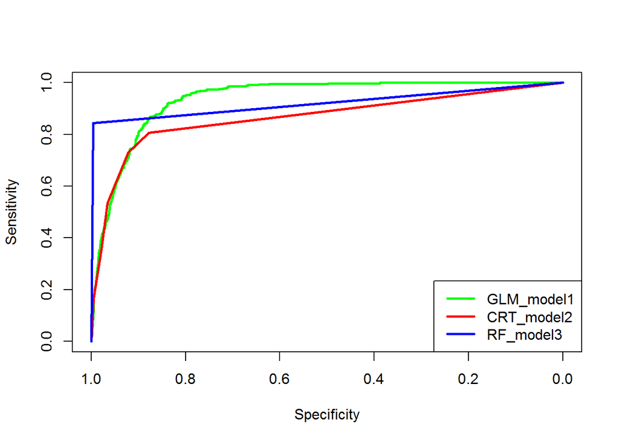

# References:

# 6 Appendix

# 6.1 Data Analysis details

## 6.1.1 Variable Description

Variable Description

[output not shown]

## 6.1.2 Predictor and Response variable Association

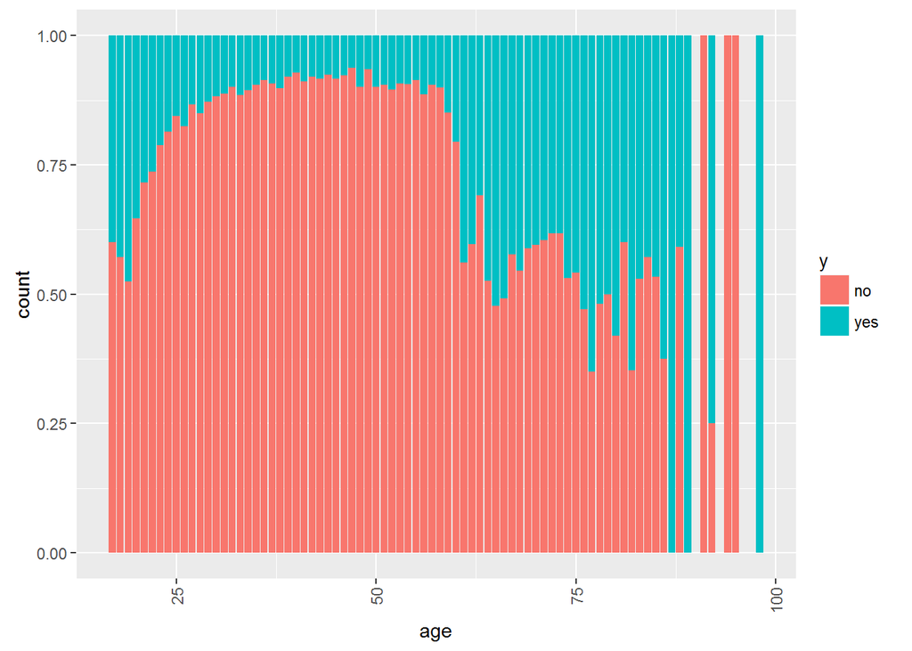

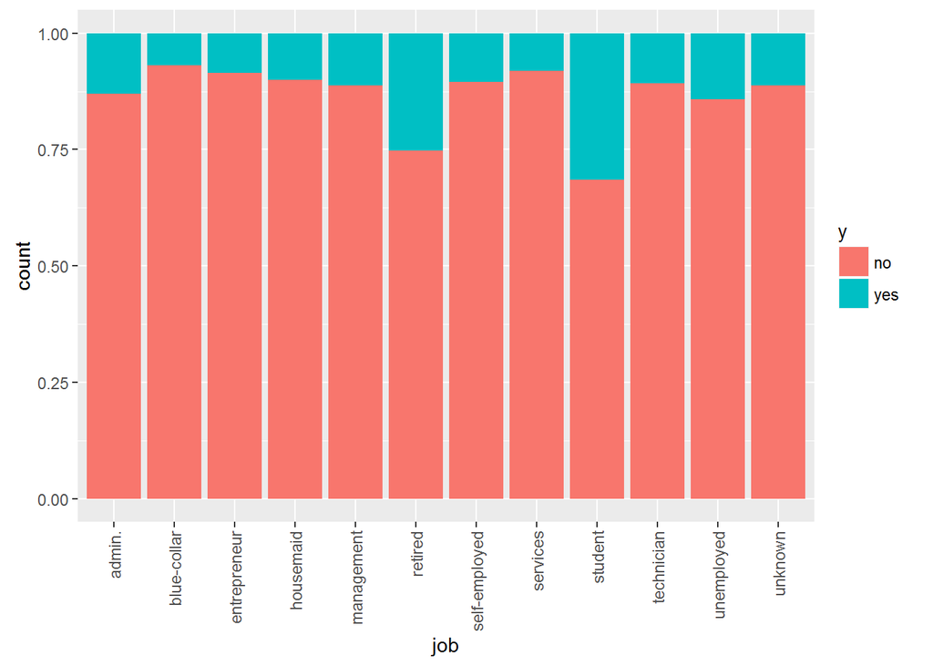

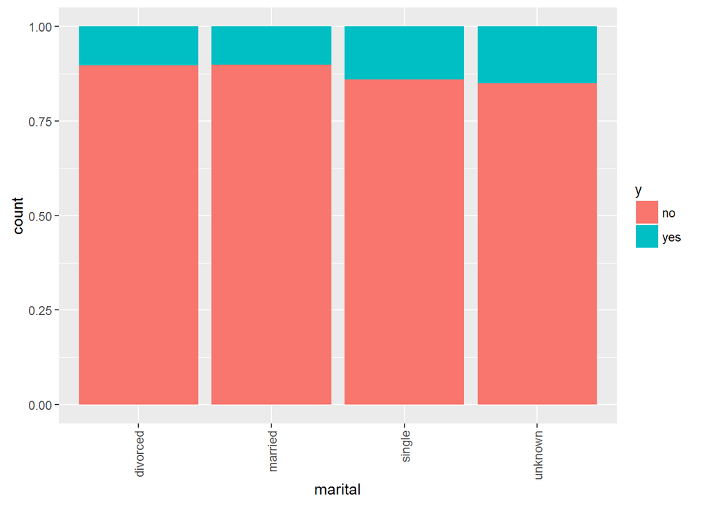

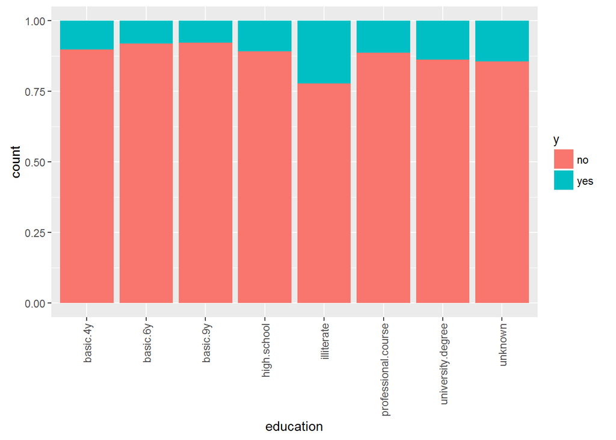

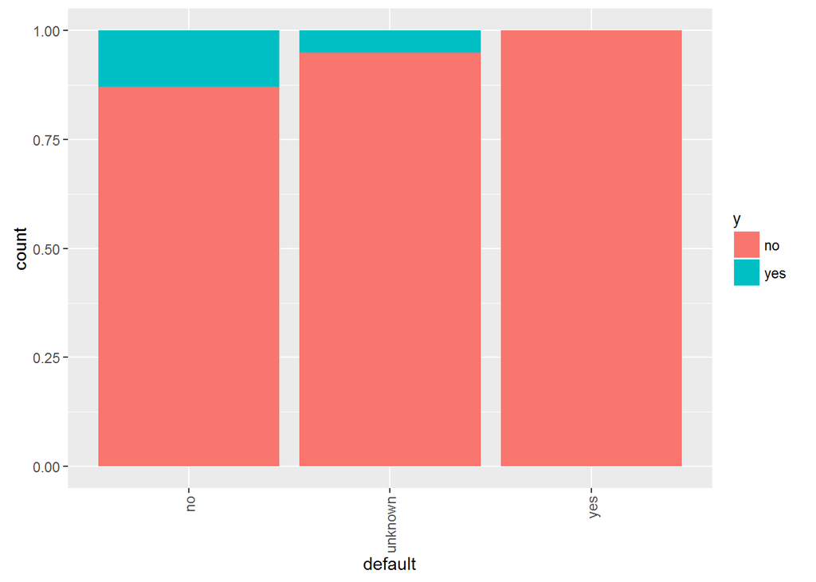

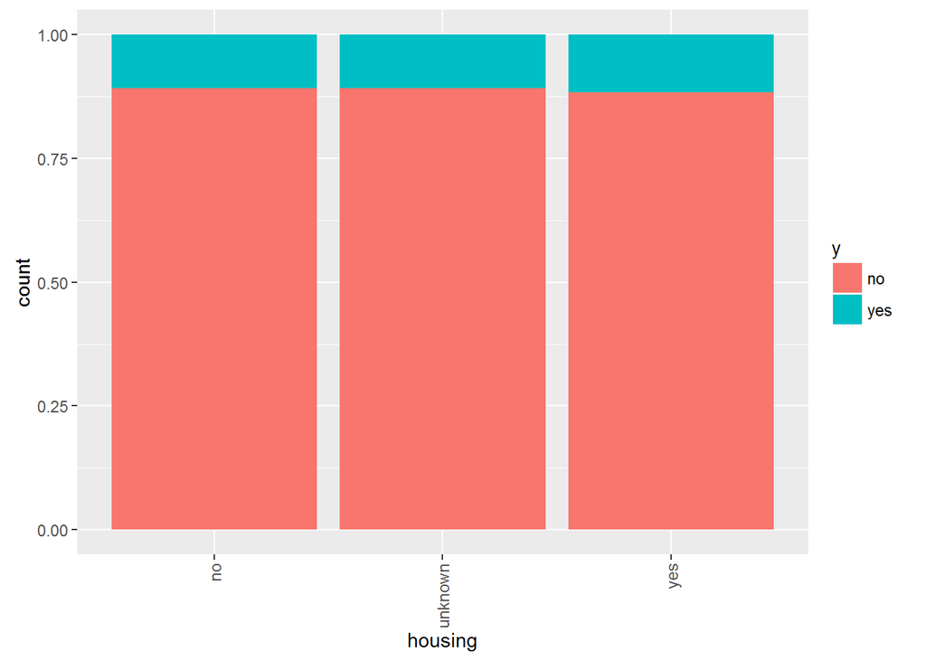

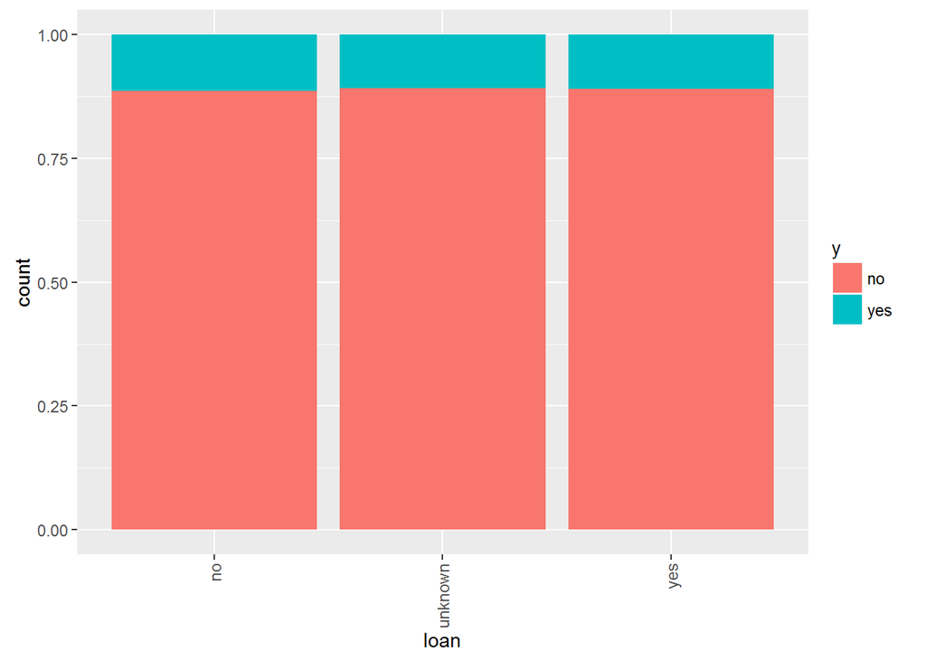

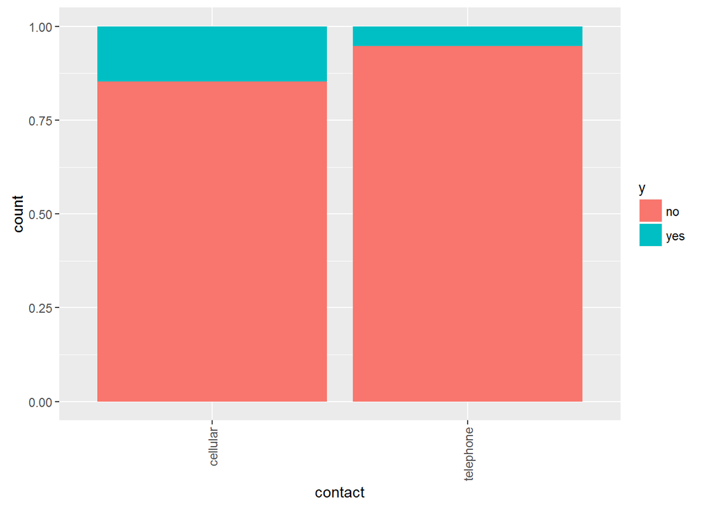

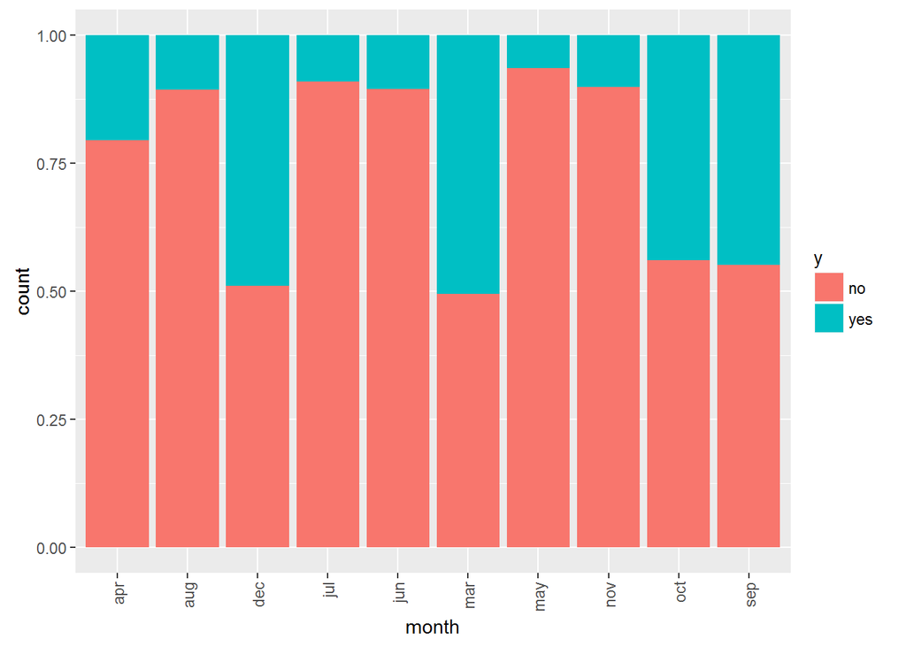

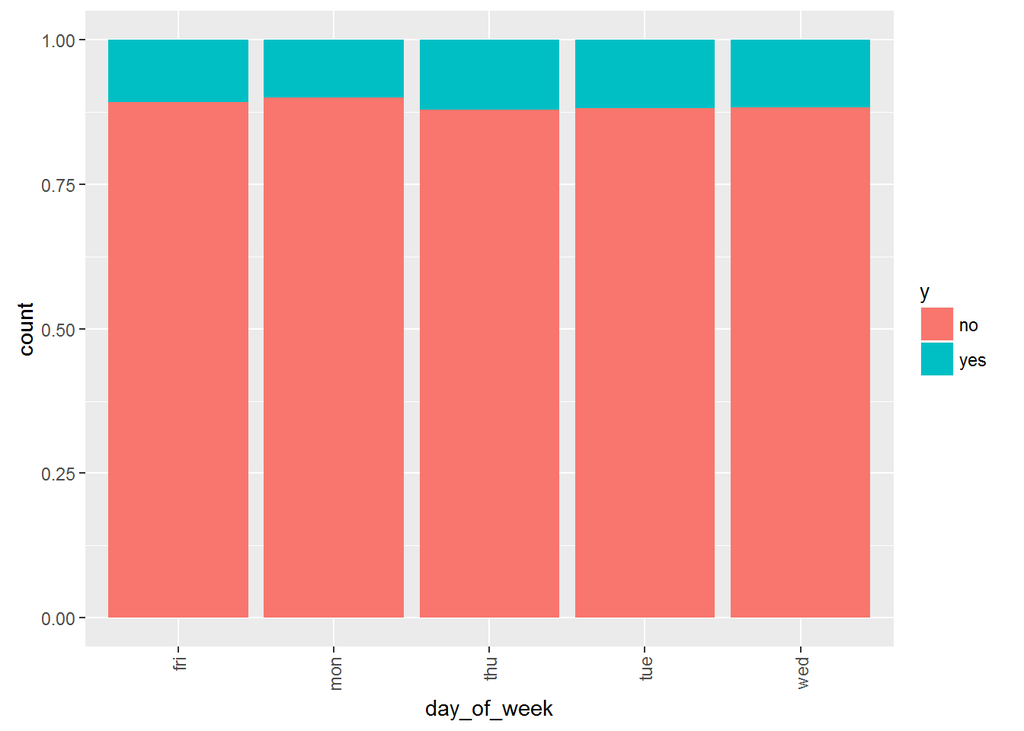

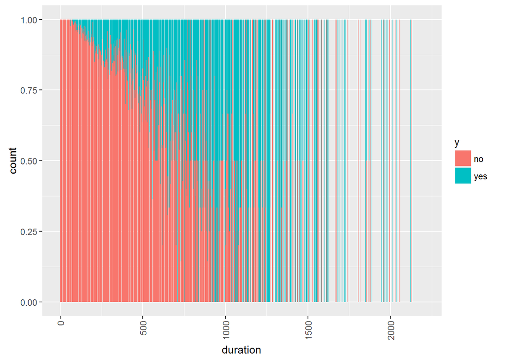

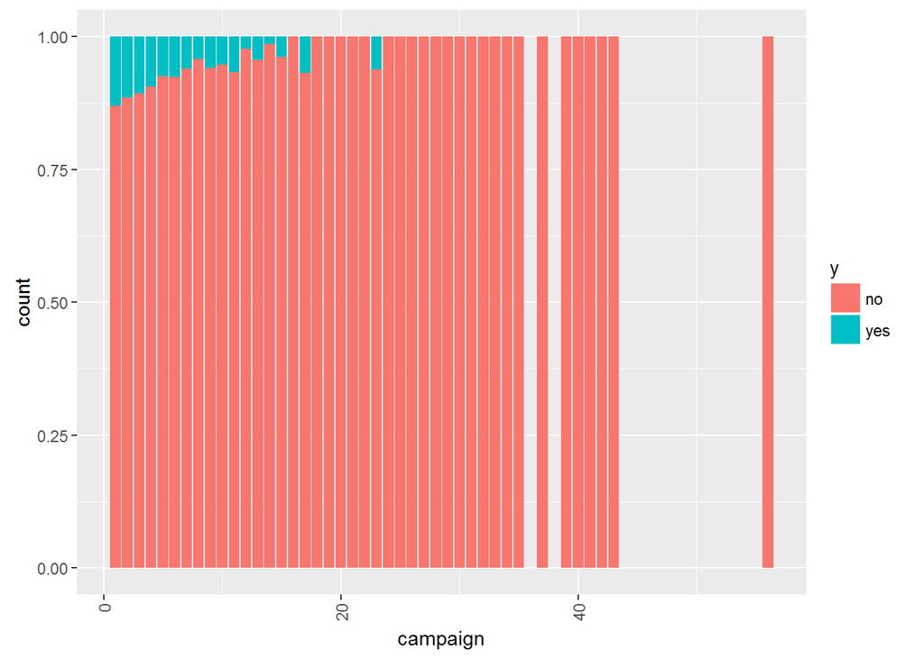

[8 more figures not shown]

## 6.1.3 Unique Value & Missing value

Missing Values

|  | Missing Values |
| --- | --- |
| age | 0 |
| job | 0 |
| marital | 0 |
| education | 0 |
| default | 0 |
| housing | 0 |
| loan | 0 |
| contact | 0 |
| month | 0 |
| day_of_week | 0 |
| duration | 0 |
| campaign | 0 |
| pdays | 0 |
| previous | 0 |
| poutcome | 0 |
| emp.var.rate | 0 |
| cons.price.idx | 0 |
| cons.conf.idx | 0 |
| euribor3m | 0 |
| nr.employed | 0 |
| y | 0 |

Unique Values

|  | Unique Values |
| --- | --- |
| age | 78 |
| job | 12 |
| marital | 4 |
| education | 8 |
| default | 3 |
| housing | 3 |
| loan | 3 |
| contact | 2 |
| month | 10 |
| day_of_week | 5 |
| duration | 1544 |
| campaign | 42 |
| pdays | 27 |
| previous | 8 |
| poutcome | 3 |
| emp.var.rate | 10 |
| cons.price.idx | 26 |
| cons.conf.idx | 26 |
| euribor3m | 316 |
| nr.employed | 11 |
| y | 2 |

## 6.1.4 Data Summary post conversion

## 6.1.5 Outliers Analysis

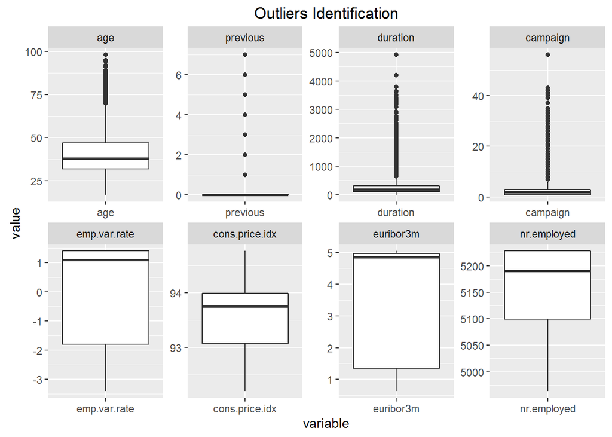

## 6.1.6 Analysis of link functions for given variables